# StatCompHomwork_21075

## 2021-11-18

## Question

一、Exercises 11.3 and 11.5 (pages 353-354, Statistical Computing with R) 二、Suppose ${T}_{1}, . . . , {T}_{n}$ are i.i.d. samples drawn from the exponential distribution with expectation $\lambda$.Those values greater than $\tau$ are not observed due to right censorship, so that the observed values are $Y_{i}=T_{i} l\left(T_{i} \leq \tau\right)+\tau l\left(T_{i}>\tau\right)$, $i=1, \ldots, n$. Suppose $\tau=1$ and the observed $Y_{i}$ values are as follows:
$$0.54,0.48,0.33,0.43,1.00,1.00,0.91,1.00,0.21,0.85$$
Use the E-M algorithm to estimate $\lambda$,compare your result with the observed data MLE (note: ${Y}_{i}$ follows a mixture distribution).

## Answer

$\mathbf{Answer1-11.3}$ Solve: The R code for this question is as follows: $\textbf{(a)Write a function to compute the k_th term：}$

```r
kth_term<-function(a,k){
  a0<-as.matrix(a)
  a_norm<-norm(a0,"2")
  d<-length(a)
  tmp<-(-1)^k*a_norm^(2*k+2)/(exp(lgamma(k+1))*2^k*(2*k+1)*(2*k+2))
  kthterm<-tmp*exp(lgamma((d+1)/2)+lgamma(k+1.5)-lgamma(k+d/2+1))
  return(kthterm)
}
kth_term(c(1,2),100)
```

```
## [1] 7.232135e-124
```

```r
kth_term(c(1,2),400)
```

```
## [1] 0
```

$\textbf{(b)Modify the function so that it computes and returns the sum：}$\ $\textbf{(c)Evaluate the sum when a=(1,2):}$

```r
kth_term<-function(a,k){
  a0<-as.matrix(a)
  a_norm<-norm(a0,"2")
  d<-length(a)
  tmp<-(-1)^k*a_norm^(2*k+2)/(exp(lgamma(k+1))*2^k*(2*k+1)*(2*k+2))
  kthterm<-tmp*exp(lgamma((d+1)/2)+lgamma(k+1.5)-lgamma(k+d/2+1))
  return(kthterm)
}
mysum<-function(a,k){
  s<-0;s0<-0
  for(i in 0:k){
  s0<-kth_term(a,i)
  s<-s+s0
  }
  return(s)
}

mysum(c(1,2),100)
```

```
## [1] 1.532164
```

```r
mysum(c(1,2),400)
```

```
## [1] 1.532164
```

$\textbf{conclusion：}$ We can see that the sum converges to 1.532164 when $a=(1,2)^{T}$

$\textbf{Answer2-11.5}$ Solve: The R code for this question is as follows:

```r
#calculate c_k

f <- function(k, u){
  tmp <- 2*exp(lgamma((k+1)/2)-0.5*log(pi*k)-lgamma(k/2))
  inte <- tmp*(1+u^2/k)^(-(k+1)/2)
  return(inte)
}

equation<-function(k, a){
  up.bound.1 <-  sqrt(a^2*(k-1)/(k-a^2))
  up.bound.2 <- sqrt(a^2*k/(k+1-a^2))

  integrate.1 <- integrate(f,lower = 0, upper = up.bound.1, k = k-1)
  integrate.2 <- integrate(f,lower = 0, upper = up.bound.2 , k = k)

  return(integrate.1$value - integrate.2$value)
}

root <- function(k){
  a <- uniroot(equation, interval = c(0.00001, sqrt(k)-0.001), k = k)$root
  return(a)
  }



k <- 2:15
for (i in k) {
 print(root(i))

}
```

```
## [1] 1.313592
## [1] 1.428227
## [1] 1.492103
## [1] 1.533547
## [1] 1.562768
## [1] 1.584422
## [1] 1.601182
## [1] 1.614522
## [1] 1.625385
## [1] 1.634409
## [1] 1.642024
## [1] 1.64854
## [1] 1.654176
## [1] 1.659098
```

$\mathbf{conclusion：}$ We can see that the solution is in similar size of the points A(k) in Exercise 11.4.

$\mathbf{Answer3：EM-algorithm}$\ Solve: The likelihood function of the i.i.d sample $T_{1}, \ldots, T_{n}$ is：
$$L(\lambda)=\prod_{i=1}^{n} \frac{1}{\lambda} \exp \left(-\frac{1}{\lambda} T_{i}\right)=(\frac{1}{\lambda})^{n} \exp \left(-\frac{1}{\lambda} \sum_{i=1}^{n} T_{i}\right)$$
Then the log likelihood function of the sample is:
$$\ln L(\lambda)=-n \ln (\lambda)-\frac{1}{\lambda} \sum_{i=1}^{n} T_{i}$$
when $Y_{i}<1$,$E\left(T_{i} \mid Y_{i}, \lambda^{(k)}\right)=Y_{i}$,\ when $Y_{i}=1$,$E\left(T_{i} \mid Y_{i}, \lambda^{(k)}\right)=E\left(T_{i} \mid T_{i} \geqslant 1, \lambda^{(k)}\right)=\lambda^{(k)}+1$\
$$\begin{aligned} \text { thus, the E-step is :} Q\left(\lambda \mid \lambda^{(k)}\right) &=E\left(\ln L(\lambda)\mid \lambda^{(k)}, \vec{y}\right)=E\left(-10 \ln \lambda-\frac{\sum_{i=1}^{10} T_{i}}{\lambda} \mid \lambda^{(k)}, \vec{y}\right) \\ &=-10 \ln \lambda-\lambda^{-1} \sum_{i=1}^{10} E\left(T_{i} \mid \lambda^{(k)},\vec{y}\right)=-10 \ln \lambda-\frac{\sum_{i=1}^{10} y_{i}+3 \lambda^{(k)}}{\lambda} \\ &=-10 \ln \lambda-\frac{6.75+3 \lambda^{(k)}}{\lambda} \\
\text {the M-step is :} \frac{\partial Q}{\partial \lambda} &=0 \Rightarrow \lambda^{(k+1)}=0.3 \lambda^{(k)}+0.675 \end{aligned}$$

The R code for this question is as follows:

```r
y <- c(0.54, 0.48, 0.33, 0.43, 1.00, 1.00, 0.91, 1.00, 0.21, 0.85)
logL <- function(lambda) {
# log-likelihood
return(-7*log(lambda)-sum(y)/lambda)
}
res <- optimize(logL,lower=0,upper=10,maximum=TRUE)
res$maximum
```

```
## [1] 0.9642879
```

```r
#the iterative formula of EM algorithm

lambda.0 <- 0.1
lambda.1 <- 0.5
while(abs(lambda.0 - lambda.1)>1e-5){
  lambda.0<- lambda.1
  lambda.1 <- lambda.0*0.3 + 0.675
}
list(MLE=res$maximum,EM_estimate=lambda.1)
```

```
## $MLE
## [1] 0.9642879
##
## $EM_estimate
## [1] 0.964283
```

$\mathbf{conclusion：}$ We can see that The EM estimate is exactly the observed data MLE,i.e.,0.96428.

## 2021-11-25

## Question

一、 Exercises 1 and 5 (page 204, Advanced R)\ 二、 Excecises 1 and 7 (page 214, Advanced R)

## Answer

$\mathbf{Answer1-11.1.2.1}$ Solve: The R code for this question is as follows:

```r
trims <- c(0, 0.1, 0.2, 0.5)
x <- rcauchy(100)
lapply(trims, function(trim) mean(x, trim = trim))
```

```
## [[1]]
## [1] 1.995804
##
## [[2]]
## [1] 0.6121799
##
## [[3]]
## [1] 0.3983687
##
## [[4]]
## [1] 0.3206039
```

```r
lapply(trims, mean, x = x)
```

```
## [[1]]
## [1] 1.995804
##
## [[2]]
## [1] 0.6121799
##
## [[3]]
## [1] 0.3983687
##
## [[4]]
## [1] 0.3206039
```

$\mathbf{conclusion：}$ The pieces of x are always supplied as the first argument to f. So if we want to vary a different argument,we can use an anonymous function.The exercise varies the amount of trimming applied when computing the mean of a fixed x,which explains why the two invocations of lapply() are equivalent.

$\textbf{Answer2-11.1.2.5}$ Solve: The R code for this question is as follows:

```r
rsq <- function(mod) summary(mod)$r.squared

#####exercise 3
mpg<-mtcars$mpg
disp<-mtcars$disp
wt<-mtcars$wt
formulas <- list(
mpg ~ disp,
mpg ~ I(1 / disp),
mpg ~ disp + wt,
mpg ~ I(1 / disp) + wt
)
#using for loop
out <- vector("list", length(formulas))
for(i in seq_along(formulas)){
  out[[i]] <- rsq(lm(formulas[[i]]))
}
out#using for loop
```

```
## [[1]]
## [1] 0.7183433
##
## [[2]]
## [1] 0.8596865
##
## [[3]]
## [1] 0.7809306
##
## [[4]]
## [1] 0.8838038
```

```r
#using lapply()
fit<-lapply(formulas, lm)
lapply(fit,rsq)#using lapply()
```

```
## [[1]]
## [1] 0.7183433
##
## [[2]]
## [1] 0.8596865
##
## [[3]]
## [1] 0.7809306
##
## [[4]]
## [1] 0.8838038
```

```r
#####exercise 4
bootstraps <- lapply(1:10, function(i) {
rows <- sample(1:nrow(mtcars), rep = TRUE)
mtcars[rows, ]
})
#using for loop
out1 <- vector("list", length(bootstraps))
for(i in seq_along(bootstraps)){
  out1[[i]] <- rsq(lm(mpg ~ disp,data = bootstraps[[i]]))
}
out1#using for loop
```

```
## [[1]]
## [1] 0.6349728
##
## [[2]]
## [1] 0.6441937
##
## [[3]]
## [1] 0.7379684
##
## [[4]]
## [1] 0.7693161
##
## [[5]]
## [1] 0.6967375
##
## [[6]]
## [1] 0.6685058
##
## [[7]]
## [1] 0.6221949
##
## [[8]]
## [1] 0.700972
##
## [[9]]
## [1] 0.615796
##
## [[10]]
## [1] 0.7254899
```

```r
#using lapply()
fit1<-lapply(bootstraps, lm, formula=mpg ~ disp)
lapply(fit1, rsq)#using lapply()
```

```
## [[1]]
## [1] 0.6349728
##
## [[2]]
## [1] 0.6441937
##
## [[3]]
## [1] 0.7379684
##
## [[4]]
## [1] 0.7693161
##
## [[5]]
## [1] 0.6967375
##
## [[6]]
## [1] 0.6685058
##
## [[7]]
## [1] 0.6221949
##
## [[8]]
## [1] 0.700972
##
## [[9]]
## [1] 0.615796
##
## [[10]]
## [1] 0.7254899
```

$\mathbf{conclusion：}$ We can see that both for loop and lapply() get the same result.

$\textbf{Answer3-11.2.5.1}$ Solve: The R code for this question is as follows:

```r
#Compute the standard deviation of every column in a numeric data frame.
df<-data.frame(replicate(6,sample(c(1:10),10,rep=T)))
round(vapply(df,sd,FUN.VALUE=c(sd=0)),3)
```

```
##    X1    X2    X3    X4    X5    X6
## 2.283 3.127 3.093 3.107 3.433 2.983
```

```r
#Compute the standard deviation of every numeric column in a mixed data frame.
mixdf<-data.frame(replicate(6,sample(c(1:10),10,rep=T)),x7=c("a","b","c","d","e","f","g","h","i","j"))
tmp<-vapply(mixdf,is.numeric,FUN.VALUE=c(c=0))
vapply(mixdf[,tmp],sd,FUN.VALUE=c(c=0))
```

```
##       X1     X1.1     X1.2     X1.3     X1.4     X1.5
## 2.368778 2.368778 2.368778 2.368778 2.368778 2.368778
```

$\textbf{Answer4-11.2.5.7}$ Solve: The R code for this question is as follows:

```r
library(parallel)
library(energy)
mcsapply <- function(x,f){
  num.clust <- makeCluster(5)
  f <- parSapply(num.clust,x,f)
  stopCluster(num.clust)
  return(f)
}

tl <- replicate(100,edist(matrix(rnorm(100),ncol=10),sizes=c(5,5)))
system.time(mcsapply(tl,function(x){return(x)}))
```

```
## 用户 系统 流逝
## 0.00 0.03 0.91
```

```r
system.time(sapply(tl,function(x){return(x)}))
```

```
## 用户 系统 流逝
##    0    0    0
```

$\mathbf{conclusion：}$ mcvapply()can implement.

## 2021-12-02

## Question

$\quad$Write an Rcpp function for Exercise 9.8 (page 278, Statistical Computing with R). $\quad$Compare the corresponding generated random numbers with pure R language using the function “qqplot”. $\quad$Campare the computation time of the two functions with the function “microbenchmark”. $\quad$Comments your results.

## Answer

The R code for this question is as follows:

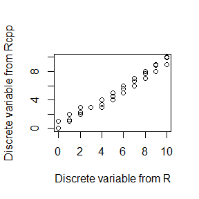

```r
#R-code
bivariate.density.R <- function(a,b,n){
  N<-5000
  burn<-1000
  X <- matrix(0, N, 2)
  X[1, ] <- c(n/2, 0.5) #initialize
  for (i in 2:N) {
    x2 <- X[i-1, 2]
    X[i, 1] <- rbinom(1, n, x2)
    x1 <- X[i, 1]
    X[i, 2] <- rbeta(1,x1+a, n-x1+b)
  }
  b <- burn + 1
  x <- X[b:N, ]
  return(x)
}

#C++code
library(Rcpp)
cppFunction('NumericMatrix bivariate_density_c(double a,double b,double n){
  int N=5000;
  int burn=1000;
  NumericMatrix X(N,2);
  NumericVector v={n/2,0.5};
  X(0,_)=v;
  for(int i=1;i<N;i++){
    double x2=X(i-1,1);
    X(i,0)=as<int>(rbinom(1,n,x2));
    int x1=X(i,0);
    X(i,1)=as<double>(rbeta(1,x1+a,n-x1+b));
  }
  NumericMatrix x=X(Range(burn-1,N-1), Range(0,1));
  return(x);
}')

#initialize
a<-1
b<-1
n<-10

#qqplot
X.R<-bivariate.density.R(a,b,n)
X.C<-bivariate_density_c(a,b,n)
x.r.1<-X.R[,1]
x.r.2<-X.R[,2]
x.c.1<-X.C[,1]
x.c.2<-X.C[,2]
qqplot(x.r.1,x.c.1,xlab = "Discrete variable from R",ylab = "Discrete variable from Rcpp")
```

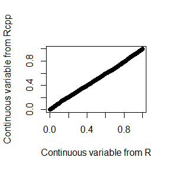

```r
qqplot(x.r.2,x.c.2,xlab = "Continuous variable from R",ylab = "Continuous variable from Rcpp")
```

```r
#Campare the computation time
library(microbenchmark)
ts <- microbenchmark(bivariate.density.R=bivariate.density.R(a,b,n), bivariate_density_c=bivariate_density_c(a,b,n))
summary(ts)[,c(1,3,5,6)]
```

```
##                  expr       lq  median      uq
## 1 bivariate.density.R 30.34485 34.0264 44.9715
## 2 bivariate_density_c  2.41230  2.8397  3.2951
```

Comments:  
1.From the figure, we conclude that if the generated chains converge, they have similar quantiles.  
2.We can conclude that the Rcpp function implement the same work as the R function do, but Rcpp function consume much less time.